# Script: SpatialACItaly

Michael Tiefelsdorf

4/05/2021

```r
##
## Extract R code from R markdown documents
##
## setwd("E:\\Lectures2021\\GISC7310\\GLSHeteroSpaAC")
## knitr::purl("SpatialACItaly.rmd")
##
```

# 1 Import data

Import the shape-files and run basic diagnostics.

```r
> setwd("E:\\Lectures2021\\GISC7310\\GLSHeteroSpaAC\\ItalyMaps")
> ##
> ## Read Poly Shapefiles (readShapePoly in library maptools)
> ##
> getinfo.shape("Provinces.shp")
```

```
R> Shapefile type: Polygon, (5), # of Shapes: 95
```

```r
> neig.shp <- rgdal::readOGR(dsn=getwd(), layer="Neighbors", integer64="warn.loss", stringsAsFactors=TRUE)
```

```
R> OGR data source with driver: ESRI Shapefile
R> Source: "E:\Lectures2021\GISC7310\GLSHeteroSpaAC\ItalyMaps", layer: "Neighbors"
R> with 19 features
R> It has 3 fields
R> Integer64 fields read as signed 32-bit integers:  ID
```

```r
> prov.shp <- rgdal::readOGR(dsn=getwd(), layer="Provinces", integer64="warn.loss", stringsAsFactors=TRUE)
```

```
R> OGR data source with driver: ESRI Shapefile
R> Source: "E:\Lectures2021\GISC7310\GLSHeteroSpaAC\ItalyMaps", layer: "Provinces"
R> with 95 features
R> It has 17 fields
R> Integer64 fields read as signed 32-bit integers:  ID LATCTRD LONGCTRD MALEPOP94 FEMPOP94 TOTPOP94
```

```r
> summary(prov.shp)
```

```
R> Object of class SpatialPolygonsDataFrame
R> Coordinates:
R>         min      max
R> x  6.614898 18.52305
R> y 35.490752 47.09521
R> Is projected: FALSE
R> proj4string : [+proj=longlat +datum=WGS84 +no_defs]
R> Data attributes:
R>        ID            AREA          PROVID        LATCTRD
R>  Min.   : 1.0   Min.   : 206   Min.   : 1.0   Min.   :36906749
R>  1st Qu.:24.5   1st Qu.:2078   1st Qu.:24.5   1st Qu.:40980025
R>  Median :48.0   Median :2754   Median :48.0   Median :43503625
R>  Mean   :48.0   Mean   :3169   Mean   :48.0   Mean   :42881681
R>  3rd Qu.:71.5   3rd Qu.:3653   3rd Qu.:71.5   3rd Qu.:45115874
R>  Max.   :95.0   Max.   :7523   Max.   :95.0   Max.   :46698170
R>
R>     LONGCTRD                 PROVNAME       REGION     RURURB
R>  Min.   : 7385709   Agrigento    : 1   Central :30   rural:86
R>  1st Qu.:10028960   Alessandria  : 1   North   :30   urban: 9
R>  Median :12133226   Ancona       : 1   Sardinia: 4
R>  Mean   :12150462   Aosta        : 1   Sicily  : 9
R>  3rd Qu.:14029612   Arezzo       : 1   South   :22
R>  Max.   :18178062   Ascoli Piceno: 1
R>                     (Other)      :89
R>    MALEPOP94          FEMPOP94          TOTPOP94         POPDENSITY
R>  Min.   :  44993   Min.   :  47333   Min.   :  92326   Min.   :  35.2
R>  1st Qu.: 135793   1st Qu.: 145345   1st Qu.: 283187   1st Qu.: 106.5
R>  Median : 200644   Median : 213233   Median : 413577   Median : 165.9
R>  Mean   : 292534   Mean   : 310293   Mean   : 602827   Mean   : 235.5
R>  3rd Qu.: 367072   3rd Qu.: 379673   3rd Qu.: 748658   3rd Qu.: 246.9
R>  Max.   :1886479   Max.   :2028089   Max.   :3914568   Max.   :2620.1
R>
R>    TOTFERTRAT     FEMMARAGE       DIVORCERAT       ILLITERRAT
R>  Min.   :0.79   Min.   :24.62   Min.   :0.0500   Min.   :0.240
R>  1st Qu.:1.00   1st Qu.:26.18   1st Qu.:0.2150   1st Qu.:0.715
R>  Median :1.12   Median :26.93   Median :0.3900   Median :1.580
R>  Mean   :1.18   Mean   :26.72   Mean   :0.4395   Mean   :2.292
R>  3rd Qu.:1.35   3rd Qu.:27.25   3rd Qu.:0.6600   3rd Qu.:3.505
R>  Max.   :1.73   Max.   :28.42   Max.   :1.0600   Max.   :7.420
R>
R>    TELEPERFAM
R>  Min.   :0.4585
R>  1st Qu.:0.7327
R>  Median :0.7907
R>  Mean   :0.7666
R>  3rd Qu.:0.8241
R>  Max.   :0.8919
R>
```

```r
> proj4string(prov.shp)                                    # map projection
```

```
R> Warning in proj4string(prov.shp): CRS object has comment, which is lost in
R> output
```

```
R> [1] "+proj=longlat +datum=WGS84 +no_defs"
```

```r
> prov.centroid <- coordinates(prov.shp)                   # Get province centroids
> prov.bbox <- bbox(prov.shp)                              # province bounding box for map region
```

# 2 Qualitative map theme of `REGION`

```r
> is.factor(prov.shp$REGION)
```

```
R> [1] TRUE
```

```r
> table(prov.shp$REGION)
```

```
R>
R>  Central    North Sardinia   Sicily    South
R>       30       30        4        9       22
```

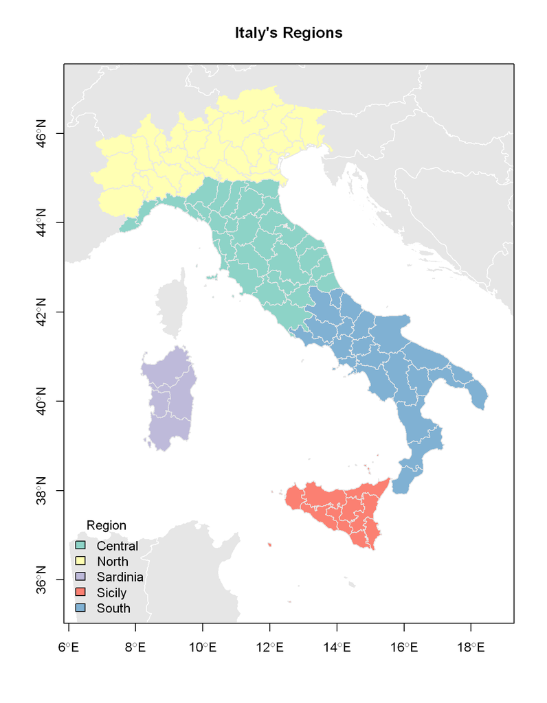

```r
> plot(neig.shp,axes=T,col=grey(0.9), border="white",      # background: neighboring countries
+      xlim=prov.bbox[1,], ylim=prov.bbox[2,])
> mapColorQual(prov.shp$REGION, prov.shp, map.title="Italy's Regions",
+                           legend.title="Region", add.to.map=T)
```

# 3 Gradient map theme of `TOTFERTRAT`

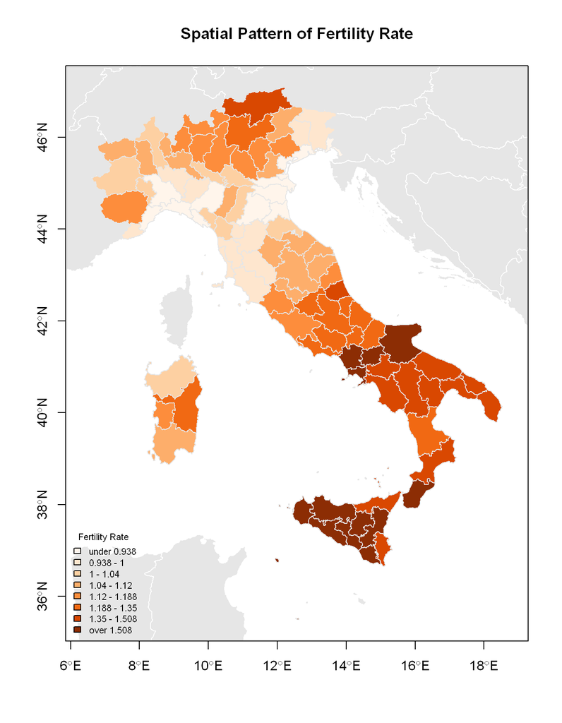

```r
> plot(neig.shp,axes=T,col=grey(0.9),border="white",       # first background (axes=T adds lat/long frame)
+      xlim=prov.bbox[1,],ylim=prov.bbox[2,])              # within bounding box
> mapColorRamp(prov.shp$TOTFERTRAT, prov.shp, breaks=8,    # second add map
+               map.title="Spatial Pattern of Fertility Rate",
+               legend.title="Fertility Rate",
+               legend.cex=0.7, add.to.map=T)
```

# 4 Basic regression model

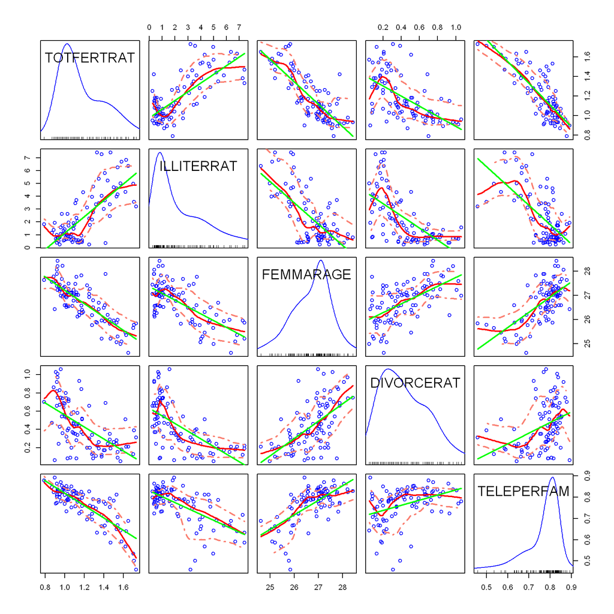

```r
> ## Regression model for fertility including model diagnostics
> scatterplotMatrix(~TOTFERTRAT+ILLITERRAT+FEMMARAGE+DIVORCERAT+TELEPERFAM, data=prov.shp,
+                    smooth=list(span = 0.35, lty.smooth=1, col.smooth="red", col.var="salmon"),
+                    regLine=list(col="green"))
```

```r
> fert.lm <- lm(TOTFERTRAT~ILLITERRAT+FEMMARAGE+DIVORCERAT+TELEPERFAM, data=prov.shp)
> summary(fert.lm,corr=F)
```

```
R>
R> Call:
R> lm(formula = TOTFERTRAT ~ ILLITERRAT + FEMMARAGE + DIVORCERAT +
R>     TELEPERFAM, data = prov.shp)
R>
R> Residuals:
R>      Min       1Q   Median       3Q      Max
R> -0.21906 -0.06267 -0.00966  0.05425  0.41272
R>
R> Coefficients:
R>              Estimate Std. Error t value Pr(>|t|)
R> (Intercept)  4.496337   0.513726   8.752 1.13e-13 ***
R> ILLITERRAT   0.020377   0.008735   2.333   0.0219 *
R> FEMMARAGE   -0.088837   0.020771  -4.277 4.71e-05 ***
R> DIVORCERAT  -0.112265   0.055648  -2.017   0.0466 *
R> TELEPERFAM  -1.226364   0.183037  -6.700 1.76e-09 ***
R> ---
R> Signif. codes:  0 '***' 0.001 '**' 0.01 '*' 0.05 '.' 0.1 ' ' 1
R>
R> Residual standard error: 0.1035 on 90 degrees of freedom
R> Multiple R-squared:  0.8096, Adjusted R-squared:  0.8012
R> F-statistic: 95.69 on 4 and 90 DF,  p-value: < 2.2e-16
```

```r
> vif(fert.lm)
```

```
R> ILLITERRAT  FEMMARAGE DIVORCERAT TELEPERFAM
R>   2.601115   2.468365   1.855334   2.088907
```

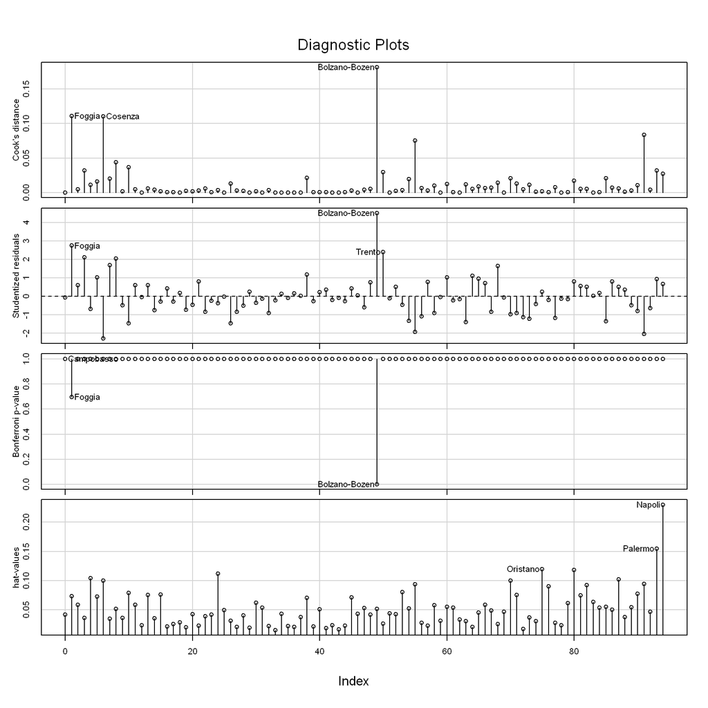

```r
> # Perform Residual Diagnostics
> influenceIndexPlot(fert.lm, id=list(n=3,labels=prov.shp$PROVNAME))
```

```r
> fertResid <- residuals(fert.lm)
```

# 5 Identify potential outlier

```r
> ## Why is Bolzano-Bozen an extreme observation? Shall we delete it?
> idx.max <- which.max(abs(fertResid))        # Get index of a record with "outlying" observation
>
> ## Map potential outlier
> extremeObs <- rep(0, length(fertResid))
> extremeObs[idx.max] <- 1
> extremeObs <- factor(extremeObs, labels=c("Population","Outlier"))
> table(extremeObs)
```

```
R> extremeObs
R> Population    Outlier
R>         94          1
```

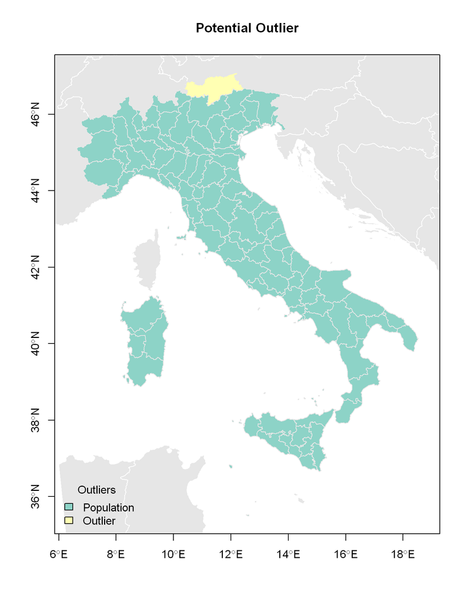

```r
> plot(neig.shp,axes=T,col=grey(0.9),border="white",                 # background: neighboring countries
+      xlim=prov.bbox[1,],ylim=prov.bbox[2,])
> mapColorQual(extremeObs, prov.shp, map.title="Potential Outlier",
+               legend.title="Outliers", add.to.map=T)
```

```r
> ## Inspect outlier
> prov.shp@data[idx.max,]                      # List info of record centre is outlier
```

```
R>    ID     AREA PROVID  LATCTRD LONGCTRD      PROVNAME REGION RURURB MALEPOP94
R> 49 50 7466.006     21 46698170 11414936 Bolzano-Bozen  North  rural    220787
R>    FEMPOP94 TOTPOP94 POPDENSITY TOTFERTRAT FEMMARAGE DIVORCERAT ILLITERRAT
R> 49   228268   449055   60.14662       1.42     27.88       0.69       0.35
R>    TELEPERFAM
R> 49    0.76808
```

```r
> ## Delete outlier or update information
> #prov.shp <- prov.shp[-idx.max ]             # Delete extreme observation from shapefile
> prov.shp@data[idx.max, "TOTFERTRAT"] <- 1.2  # Or change its value within the shapefile
>
> ## Continue with updated dataset
> fert.lm <- lm(TOTFERTRAT~ILLITERRAT+FEMMARAGE+DIVORCERAT+TELEPERFAM,data=prov.shp) # update model
> summary(fert.lm)
```

```
R>
R> Call:
R> lm(formula = TOTFERTRAT ~ ILLITERRAT + FEMMARAGE + DIVORCERAT +
R>     TELEPERFAM, data = prov.shp)
R>
R> Residuals:
R>       Min        1Q    Median        3Q       Max
R> -0.219546 -0.059570 -0.008288  0.055215  0.256479
R>
R> Coefficients:
R>              Estimate Std. Error t value Pr(>|t|)
R> (Intercept)  4.625004   0.476205   9.712 1.13e-15 ***
R> ILLITERRAT   0.021280   0.008097   2.628   0.0101 *
R> FEMMARAGE   -0.095354   0.019254  -4.953 3.41e-06 ***
R> DIVORCERAT  -0.111163   0.051584  -2.155   0.0338 *
R> TELEPERFAM  -1.173424   0.169668  -6.916 6.54e-10 ***
R> ---
R> Signif. codes:  0 '***' 0.001 '**' 0.01 '*' 0.05 '.' 0.1 ' ' 1
R>
R> Residual standard error: 0.09594 on 90 degrees of freedom
R> Multiple R-squared:  0.8345, Adjusted R-squared:  0.8272
R> F-statistic: 113.5 on 4 and 90 DF,  p-value: < 2.2e-16
```

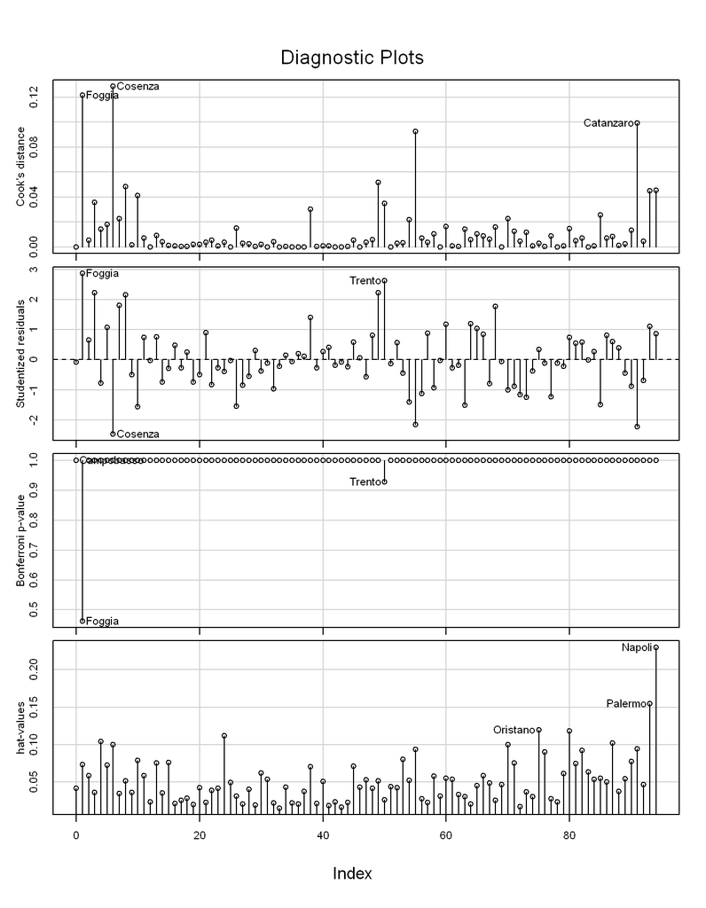

```r
> influenceIndexPlot(fert.lm, id=list(n=3, labels=prov.shp$PROVNAME))
```

# 6 Check for heteroscedasticity

```r
> ## Check for heteroscedasticity
> fert.fgls <- lmHetero(TOTFERTRAT~ILLITERRAT+FEMMARAGE+DIVORCERAT+TELEPERFAM | log(FEMPOP94),
+                       data=prov.shp)
> summary(fert.fgls)
```

```
R>
R> ================================================================
R> Multiplicatively Weighted Heteroscedasticity ML-Regression Model
R> ================================================================
R>
R> Call:
R> lmHetero(formula = TOTFERTRAT ~ ILLITERRAT + FEMMARAGE + DIVORCERAT +
R>     TELEPERFAM | log(FEMPOP94), data = prov.shp)
R>
R> Regression Coefficients:
R>               Estimate    Std.Err z-value  Pr(>|z|)
R> (Intercept)  4.3881835  0.4265870 10.2867 < 2.2e-16 ***
R> ILLITERRAT   0.0286213  0.0074558  3.8388 0.0001236 ***
R> FEMMARAGE   -0.0894065  0.0174198 -5.1325 2.860e-07 ***
R> DIVORCERAT  -0.1073668  0.0441414 -2.4323 0.0150017 *
R> TELEPERFAM  -1.1055990  0.1775114 -6.2283 4.714e-10 ***
R> ---
R> Signif. codes:  0 '***' 0.001 '**' 0.01 '*' 0.05 '.' 0.1 ' ' 1
R>
R> Gamma Coefficients:
R>                   Gamma   Std.Err z-value  Pr(>|z|)
R> (Intercept)   -12.60936   2.56690 -4.9123 9.001e-07 ***
R> log(FEMPOP94)   0.63263   0.20748  3.0492  0.002295 **
R> ---
R> Signif. codes:  0 '***' 0.001 '**' 0.01 '*' 0.05 '.' 0.1 ' ' 1
R>
R> log-likelihood = 92.96326
R>
R> Heteroscedasticity likelihood ratio test:
R>        LR   df  Pr(Chi > LR)
R>  5.019431    1    0.02506441
```

This is marginal significant, thus the heteroscedastic model and will be used subsequently for demonstration purposes.

Therefore, the lm-model is updated to a **weighted lm-model**.

```r
> fert.wlm <- lm(TOTFERTRAT~ILLITERRAT+FEMMARAGE+DIVORCERAT+TELEPERFAM, data=prov.shp,
+                weights=fert.fgls$weights)
```

# 7 Bipolar map theme of regression residual

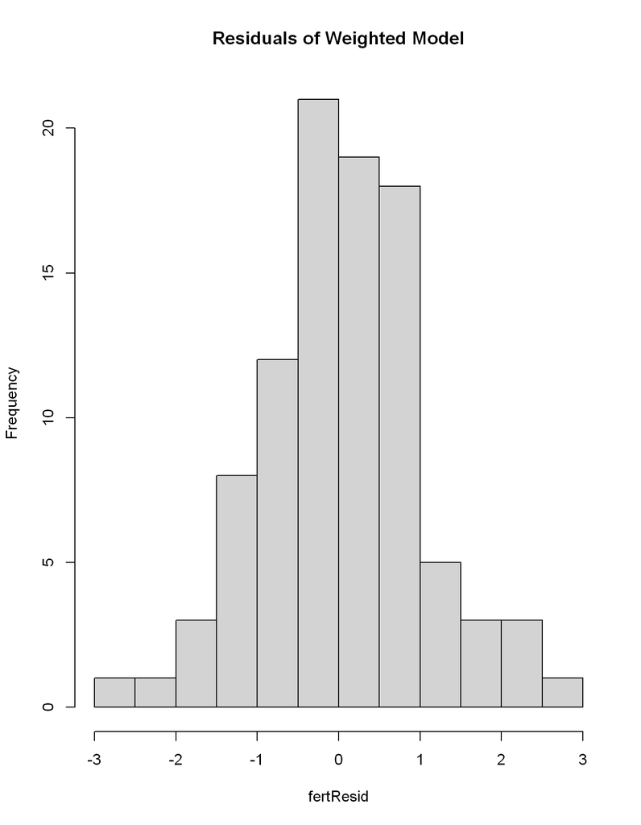

```r
> ## Plot Regression Residuals (Bi-polar)
> fertResid <- weighted.residuals(fert.wlm)                # Update residuals
> hist(fertResid, main="Residuals of Weighted Model")      # Explore distribution to
```

```r
> length(fertResid[fertResid < 0])                         # identify number of pos/neg classes
```

```
R> [1] 46
```

```r
> length(fertResid[fertResid >= 0])
```

```
R> [1] 49
```

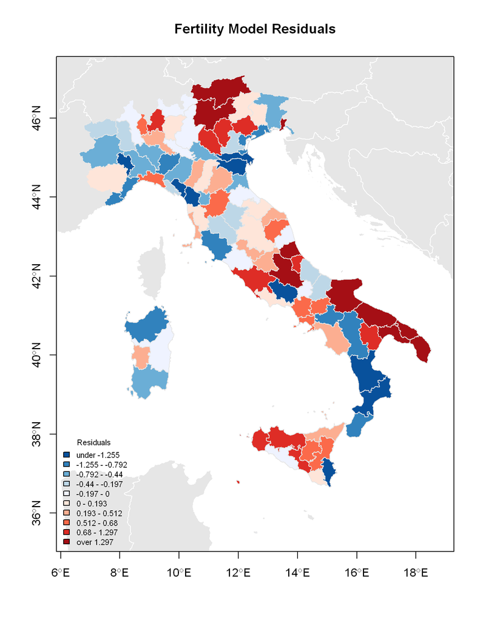

```r
> plot(neig.shp,axes=T,col=grey(0.9),border="white",
+      xlim=prov.bbox[1,],ylim=prov.bbox[2,])               # first background
> mapBiPolar(fertResid, prov.shp,                           # second regression residuals
+             neg.breaks=5, pos.breaks=5, break.value=0.0,
+             map.title="Fertility Model Residuals",
+             legend.title="Residuals",
+             legend.cex=0.7, add.to.map=T)
```

The map pattern indicates that there are spatial clusters with positive and negative regression residuals. Thus the **spatial independence assumption** is violated.

# 8 Identify the linkage structure

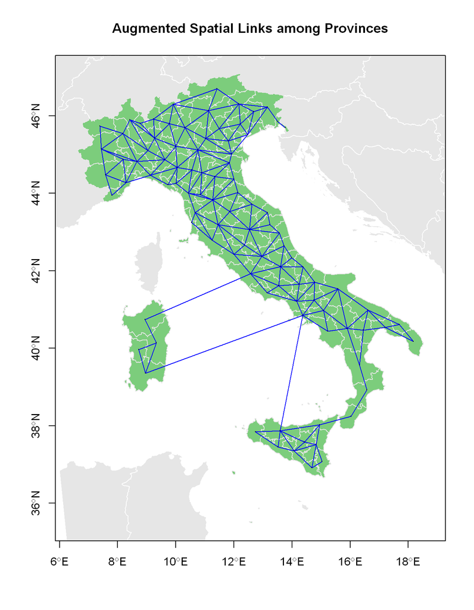

```r
> ## Plot Augmented Spatial Links among Italian Provinces
> ## Notes: Shape file has been edited so satellite islands are connected to mainland
> ## Alternatively spdep::edit.nb function (does not work with RStudio)
> prov.link <- poly2nb(prov.shp, queen=F)                          # Generate neighbors links
>
> plot(neig.shp,axes=T,col=grey(0.9),border="white",
+      xlim=prov.bbox[1,],ylim=prov.bbox[2,])                      # First background
> plot(prov.shp,col="palegreen3" ,border=grey(0.9), axes=T, add=T) # Second plot areas
> plot(prov.link,coords=prov.centroid, pch=19, cex=0.1,            # Third plot links focused at centroids
+      col="blue", add=T)
> title("Augmented Spatial Links among Provinces")                 # Forth add title
> box()                                                            # Fifth refresh frame
```

# 9 Perform a test for spatial autocorrelation in the residuals

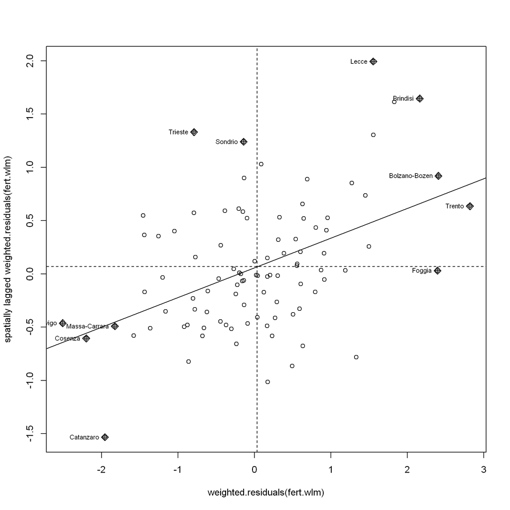

```r
> prov.linkW <- nb2listw(prov.link, style="W")                   # generated row-sum standardized neighbors list
> spOutliers <- moran.plot(weighted.residuals(fert.wlm),         # Moran plot with outlier diagnositics
+                          prov.linkW, labels=prov.shp$PROVNAME)
```

```r
> lm.morantest(fert.wlm, prov.linkW)                             # Test with W-coding scheme
```

```
R>
R>  Global Moran I for regression residuals
R>
R> data:
R> model: lm(formula = TOTFERTRAT ~ ILLITERRAT + FEMMARAGE + DIVORCERAT +
R> TELEPERFAM, data = prov.shp, weights = fert.fgls$weights)
R> weights: prov.linkW
R>
R> Moran I statistic standard deviate = 4.5306, p-value = 2.941e-06
R> alternative hypothesis: greater
R> sample estimates:
R> Observed Moran I      Expectation         Variance
R>      0.281242173     -0.029598120      0.004707174
```

Also look up `help(lm.morantest)`. Internally weighted regression residuals are used.

# 10 Maximum likelihood estimation of SAR

Check the online help for the `spatialreg::spautolm( )` function. Note the use of the `weights` option here. When the `weights` option is used `spautolm` requires a full specification of the model rather than just using the `fert.wlm` object.

```r
> fert.SAR <- spautolm(TOTFERTRAT~ILLITERRAT+FEMMARAGE+DIVORCERAT+TELEPERFAM,
+                      data=prov.shp, weights = fert.fgls$weights,
+                      na.action="na.omit", listw=prov.linkW, family="SAR")
> summary(fert.SAR)
```

```
R>
R> Call: spautolm(formula = TOTFERTRAT ~ ILLITERRAT + FEMMARAGE + DIVORCERAT +
R>     TELEPERFAM, data = prov.shp, listw = prov.linkW, weights = fert.fgls$weights,
R>     na.action = "na.omit", family = "SAR")
R>
R> Residuals:
R>        Min         1Q     Median         3Q        Max
R> -0.1346010 -0.0515529  0.0066078  0.0595509  0.2377229
R>
R> Coefficients:
R>               Estimate Std. Error z value  Pr(>|z|)
R> (Intercept)  3.1164030  0.4694416  6.6385 3.168e-11
R> ILLITERRAT   0.0166445  0.0089083  1.8684  0.061701
R> FEMMARAGE   -0.0484661  0.0178010 -2.7227  0.006476
R> DIVORCERAT  -0.0309038  0.0378188 -0.8172  0.413840
R> TELEPERFAM  -0.9134920  0.1668045 -5.4764 4.340e-08
R>
R> Lambda: 0.76152 LR test value: 23.96 p-value: 9.8382e-07
R> Numerical Hessian standard error of lambda: 0.092528
R>
R> Log likelihood: 104.943
R> ML residual variance (sigma squared): 0.63854, (sigma: 0.79909)
R> Number of observations: 95
R> Number of parameters estimated: 7
R> AIC: -195.89
```

The likelihood ratio test of the SAR model is identically to the hand calculated one. Important here is a slight difference in the calculation when heteroscedasticity is incorporated.

```r
> ## Likelihood Ratio test (identical to LR from spautolm)
> #(likeH0 <- logLik(fert.lm))                     # Use for unweighted model
> (likeH0 <- fert.fgls$logLikeH1)
```

```
R> [1] 92.96326
```

```r
> (likeH1 <- logLik(fert.SAR))
```

```
R> 'log Lik.' 104.943 (df=7)
```

```r
> cat("chi-square value:  ", chi <- -2*(likeH0[1]-likeH1[1]))
```

```
R> chi-square value:   23.95954
```

```r
> cat("error-probability: ", pchisq(chi, df=1, lower.tail=F))
```

```
R> error-probability:  9.838169e-07
```

Thus the SAR model improves significantly over the heteroscedastic model.

Check whether the residuals are as expected free of spatial autocorrelation. Because the distribution of ML residuals in unknown, Morans’s $I$ is evaluated here using a **randomization approach**.

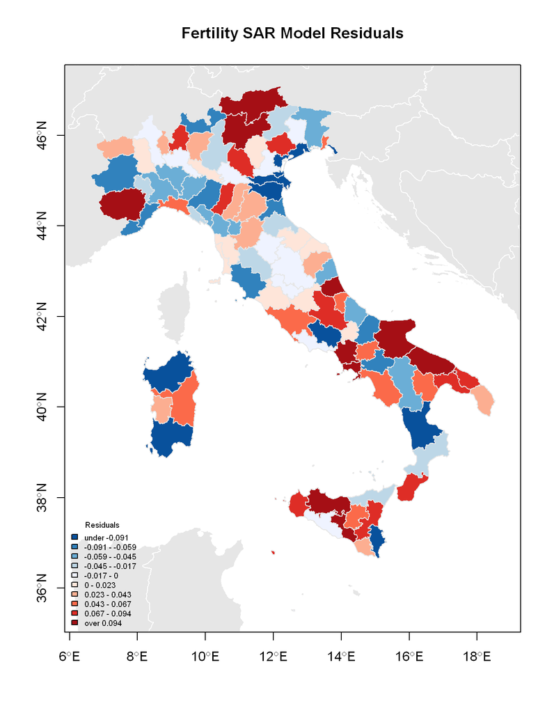

```r
> ## Moran test applying randomization because ML may not be normal distributed
> plot(neig.shp,axes=T,col=grey(0.9),border="white",
+      xlim=prov.bbox[1,],ylim=prov.bbox[2,])                        # first background
> mapBiPolar(residuals(fert.SAR), prov.shp,                          # second regression residuals
+             neg.breaks=5, pos.breaks=5, break.value=0.0,
+             map.title="Fertility SAR Model Residuals",
+             legend.title="Residuals", legend.cex = 0.6,
+             add.to.map=T)
```

```r
> ## Evaluate ML residuals for spatial autocorrelation
> moran.mc(residuals(fert.SAR), prov.linkW, nsim=9999, alternative="less")
```

```
R>
R>  Monte-Carlo simulation of Moran I
R>
R> data:  residuals(fert.SAR)
R> weights: prov.linkW
R> number of simulations + 1: 10000
R>
R> statistic = -0.060189, observed rank = 2414, p-value = 0.2414
R> alternative hypothesis: less
```